## Statistical report

This document is a statistical report on the dataset used in our project.  
The dataset contains anonymous ratings(-10 to 10) provided by a total of 41,000 users. Train file contains 1.1 million ratings for 139 jokes.

Here we load the data and create the dataframe.

```r
library("ggplot2")
trainSet <- read.csv("train.csv")
df <- data.frame(trainSet)
```

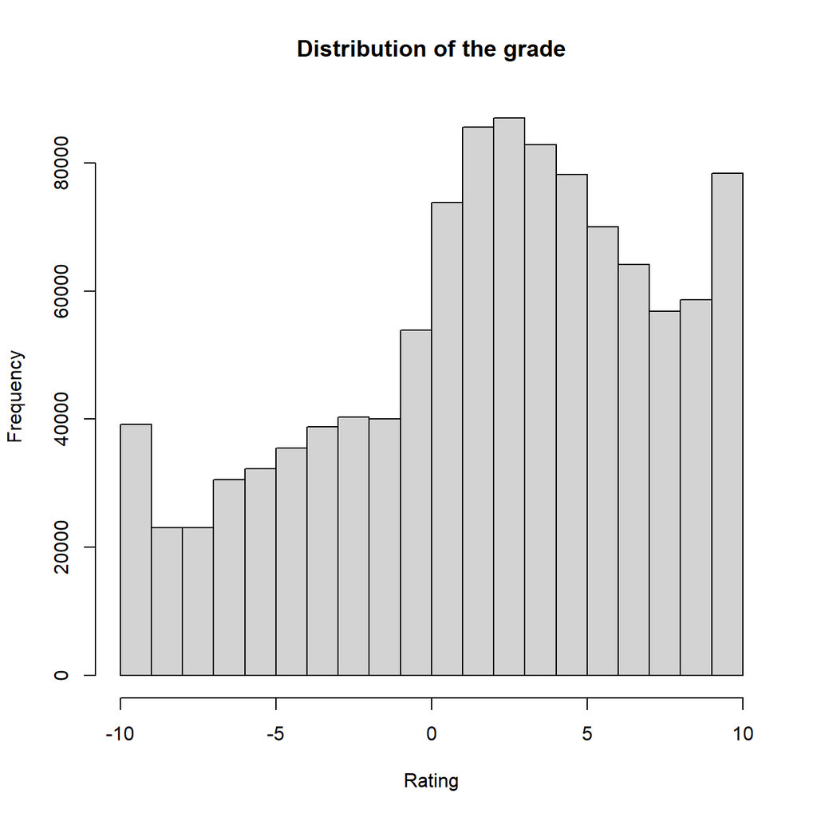

```r
hist(df$Rating,main = "Distribution of the grade", xlab = "Rating")
```

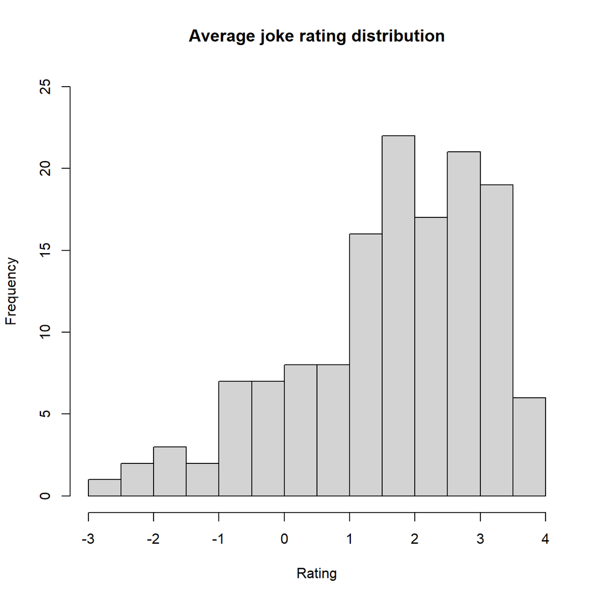

```r
average_ratings <- aggregate(df$Rating ~ df$joke_id, df, mean)
hist(average_ratings$`df$Rating`,ylim=c(0,25), breaks = 20, main = "Average joke rating distribution", xlab = "Rating")
```

Here is a histogram representing number of ratings distribution. As we can see, the popularity of jokes is different. While some jokes have more than 25,000 ratings, others do not even reach 1000 ratings.

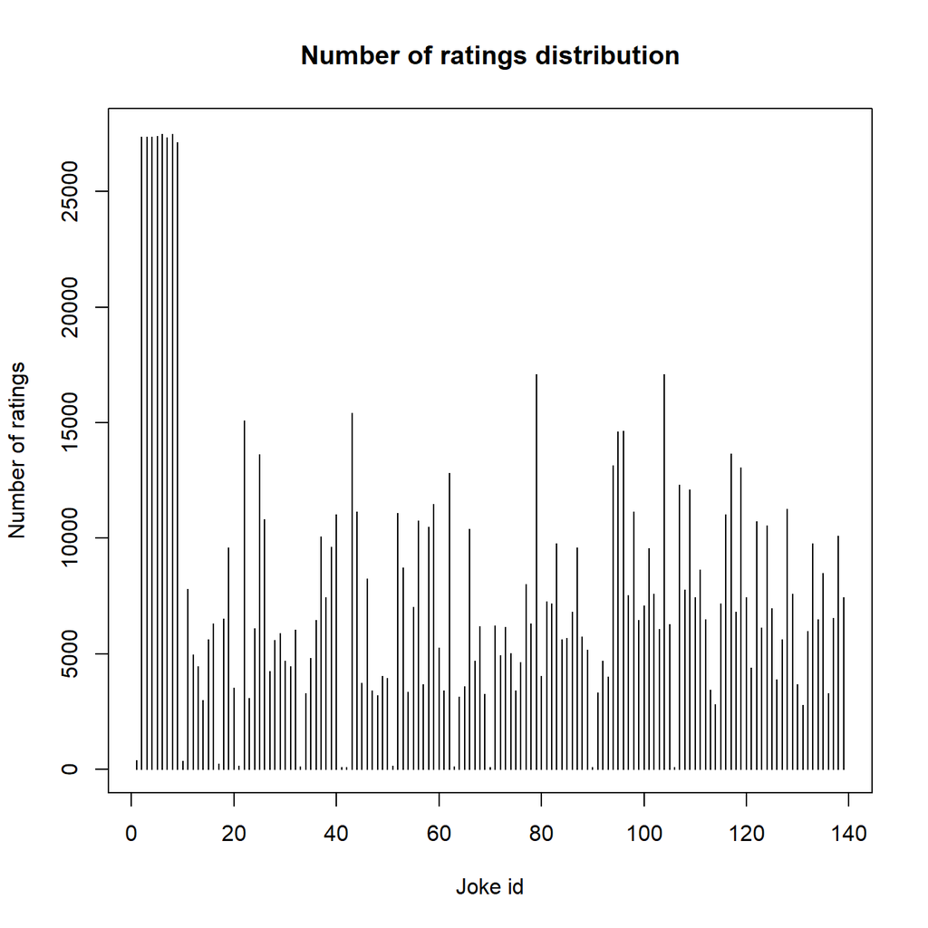

```r
ratings_numbers <- aggregate(df$Rating ~ df$joke_id, df, length)
plot(ratings_numbers, type = "h", breaks = 139, main = "Number of ratings distribution", xlab = "Joke id", ylab = "Number of ratings")
```

Here is a histogram representing standard deviations of jokes ratings distribution. As we can see, the standard deviations form a normal distribution. From this we can conclude that the ratings of jokes are compatible.

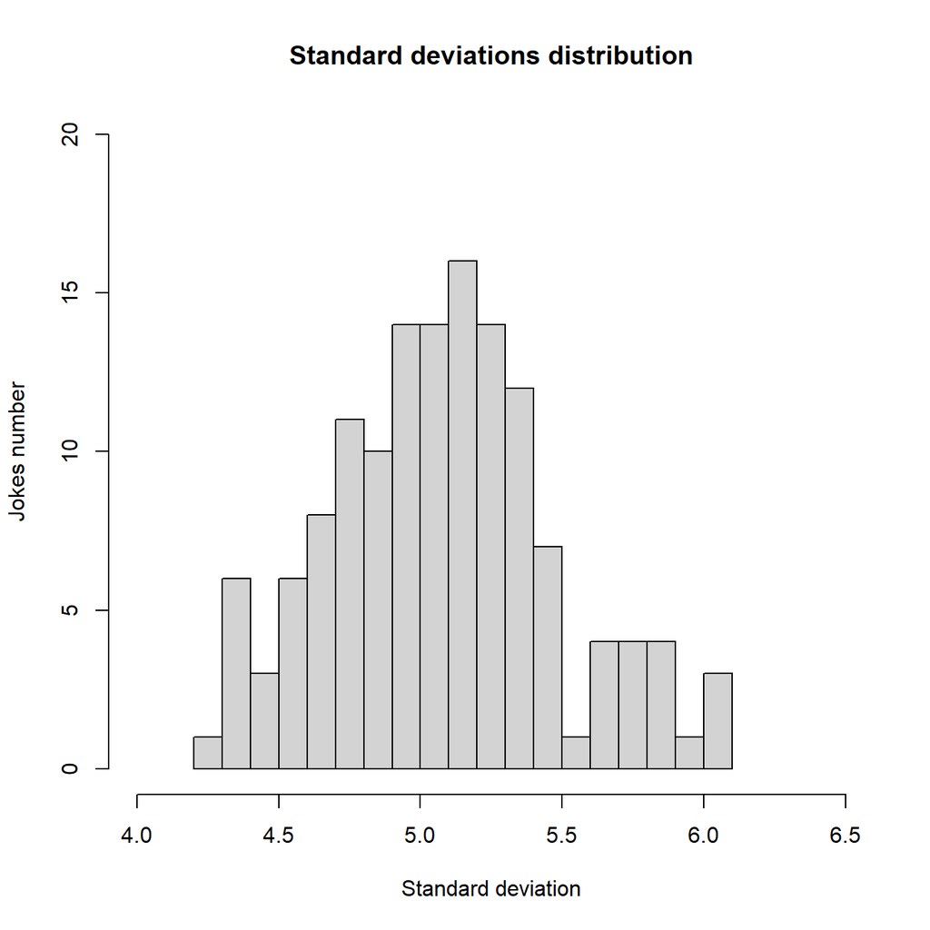

```r
standard_deviations <- aggregate(df$Rating ~ df$joke_id, df, sd)
hist(standard_deviations$`df$Rating`, xlim = c(4, 6.5),ylim=c(0,20), breaks = 20, main="Standard deviations distribution", xlab = "Standard deviation",
     ylab = "Jokes number")
```